# Diffusion Curve Generator Output

21 October, 2019

# 1. Introduction

The method takes probability distributions for three diffusion parameters to generate curves based on the Bass Model of Product Diffusion. The parameters, $m$, $N1$ and $t'$, represent the maximum number of adoptions attained, the number of adoptions in the first year and the time at which the rate of diffusion reduces, respectively.

# 2. Elicitation Input

Input distributions

```
##      Expert                  M                N1                 t'
## 1: Expert A  Gamma(3.03, 0.06) Gamma(4.19, 1.88) Gamma(22.21, 4.36)
## 2: Expert B Gamma(12.37, 0.08) Gamma(5.08, 0.91) Gamma(38.27, 3.84)
## 3: Expert C  Gamma(2.81, 0.01) Gamma(11.1, 1.67) Gamma(14.35, 4.06)
```

Distributions of the input parameters (200 samples). The parameters were sampled from mixture distributions.

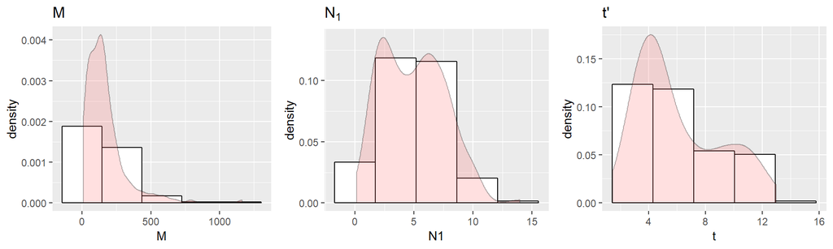

Summary of sample input parameters

```
##        M                  N1               t
##  Min.   :   7.017   Min.   : 0.133   Min.   : 1.478
##  1st Qu.:  72.692   1st Qu.: 2.666   1st Qu.: 3.751
##  Median : 134.970   Median : 4.956   Median : 4.907
##  Mean   : 165.216   Mean   : 4.971   Mean   : 6.039
##  3rd Qu.: 202.861   3rd Qu.: 6.980   3rd Qu.: 8.267
##  Max.   :1166.054   Max.   :13.976   Max.   :12.974
```

# 3. Parameter fitting

Distributions of the fitted parameters (200 samples).

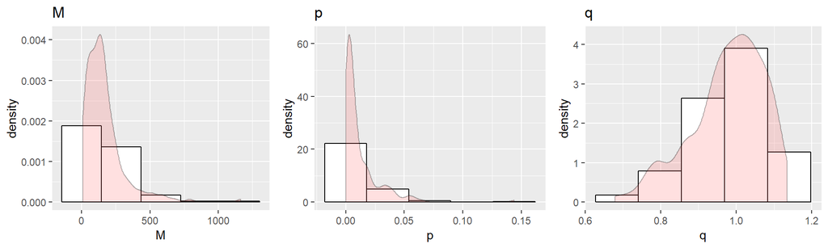

```
##        M                  p                   q
##  Min.   :   7.017   Min.   :0.0002257   Min.   :0.6789
##  1st Qu.:  72.692   1st Qu.:0.0019630   1st Qu.:0.9314
##  Median : 134.970   Median :0.0054897   Median :0.9912
##  Mean   : 165.216   Mean   :0.0117778   Mean   :0.9774
##  3rd Qu.: 202.861   3rd Qu.:0.0156785   3rd Qu.:1.0475
##  Max.   :1166.054   Max.   :0.1439144   Max.   :1.1351
```

# 4. Generated diffusion curves

Generated diffusion curves.

- $N(t)$ Number of cumulated adoptions at $t$
- $dN(t)$ New adoptions at $t$

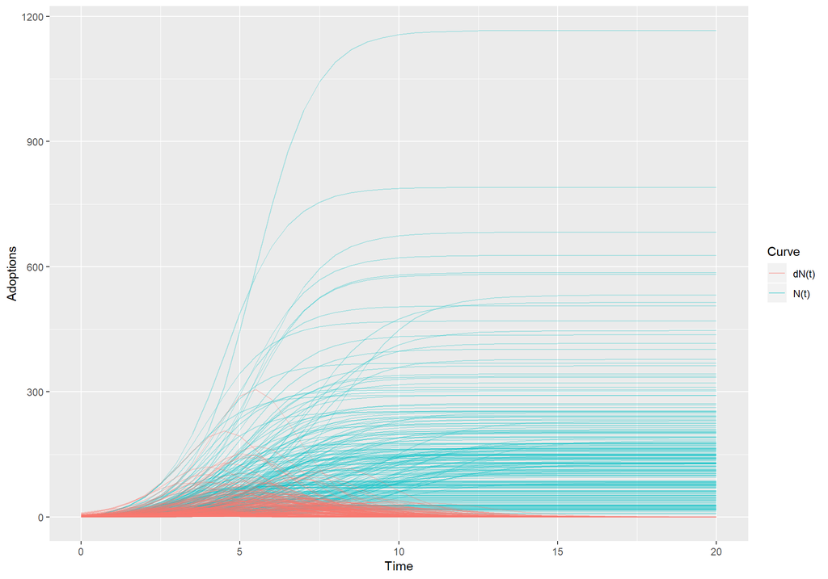

Average curves (median)

```
##  Time      N    dN
##     0   0.00  0.62
##     2   3.71  4.06
##     4  22.93 14.07
##     6  64.35 17.75
##     8  96.38 11.03
##    10 121.94  1.77
##    12 129.95  0.25
##    14 133.64  0.03
##    16 134.63  0.00
##    18 134.90  0.00
##    20 134.96  0.00
```

## Reference

Grimm SE, Stevens JW, Dixon S. Estimating Future Health Technology Diffusion Using Expert Beliefs Calibrated to an Established Diffusion Model. Value Health. 2018 Aug;21(8):944-950.